# Transformada de Fourier

Materia: Aprendizaje Automático

Integrantes: Gonzalo Jara y Tomás Gómez

Docente: Esteban Roitberg

# Contexto del problema

Ella se llama Ciri.

[figure not shown]

Queremos usar la imágen en un modelo.

La imagen es de 3072 x 4080 y pesa 636KB.

**¿Cómo podemos simplificarla sin perder información valiosa?**

**Podemos comprimirla usando la Transformada de Fourier**

## Un caso más simple, ¿Cómo simplificar una señal?

Si tengo una señal con ruido, y quiero eliminarlo, ¿cómo hago?

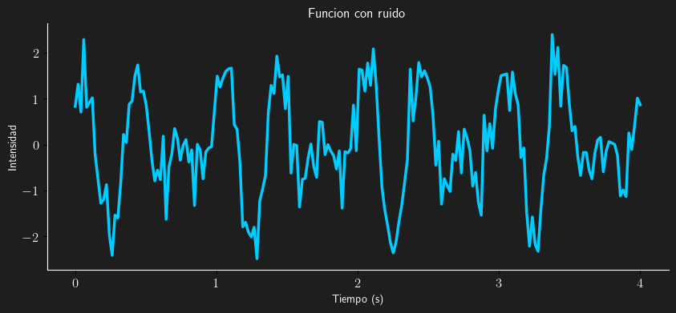

## La respuesta: Series de Fourier

Las Series de Fourier nos permiten descomponer cualquier señal periódica en una serie infinita de senos y cosenos.

[video not shown]

## Definición de la Serie de Fourier

Dada una función $f(x)$ periódica de período $P$, su serie de Fourier se define como: $$ S_N(x) = a_0 \sum_{n=1}^{N}(a_n cos(2 \pi \frac{n}{P} x) + b_n sin(2 \pi \frac{n}{P} x)) $$ con coeficientes: $$ a_0 = \frac{1}{P} \int_{P}{}f(x)dx \\ a_n = \frac{2}{P} \int_{P}{}f(x) cos(2 \pi \frac{n}{P} x) dx \\ b_n = \frac{2}{P} \int_{P}{}f(x) sin(2 \pi \frac{n}{P} x) dx $$

Las series de Fourier son muy útiles ya que nos permiten expresar una aproximación de cualquier función periódica de forma muy sencilla de calcular (senos y cosenos).

Pero, para poder comprimir una imagen, necesitamos algo más general, que pueda analizar funciones no periódicas...

## ¿Qué es la Transformada de Fourier?

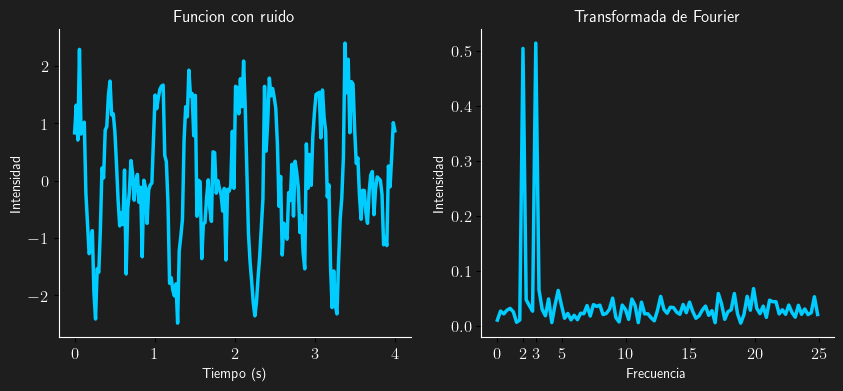

## Formula de Euler

Para cualquier número real x: $$ e^{ix} = cos(x) + i sen(x) $$ Esto nos permite relacionar senos y cosenos con números complejos, los cuales pueden pensarse como vectores.

[video not shown]

## ¿Cómo funciona la Transformada de Fourier?

$$ \hat f(\epsilon) = \int_{-\infty}^{\infty} f(x) e^{-i 2 \pi \epsilon x} dx $$

Donde:

- $f(x)$ es la funcion original.
- $\epsilon$ es una variable que representa a la frecuencia de la función original.
- $e^{-i 2 \pi}$ es un número complejo que depende de $x$ y de $\epsilon$.

$$ f(x) e^{-i 2 \pi \epsilon x} $$

[video not shown]

$$ \hat f(\epsilon) = \int_{-\infty}^{\infty} f(x) e^{-i 2 \pi \epsilon x} dx $$

[video not shown]

## Función final de la transformada de Fourier

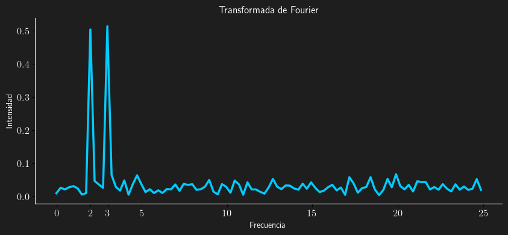

Determinamos un umbral para filtrar el ruido

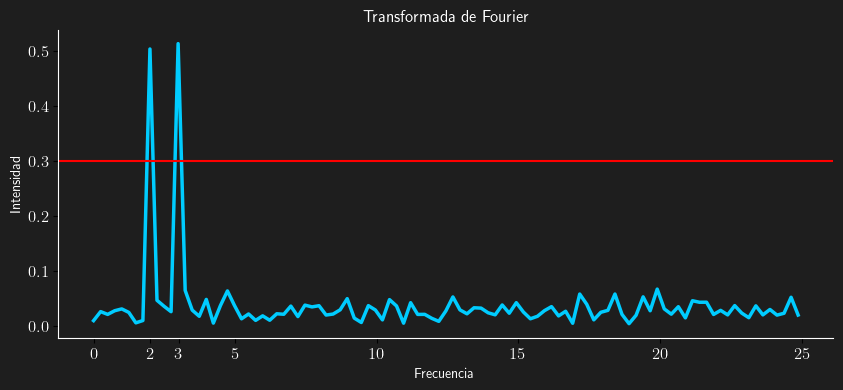

Filtramos el ruido y reconstruimos la señal con la inversa de la transformada de Fourier.

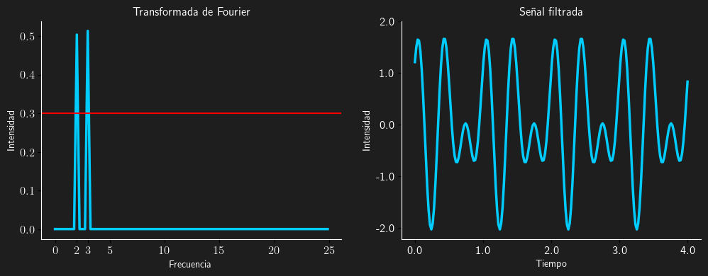

## Comprimiendo a Ciri

Pasamos la imagen de Ciri a escala de grises para hacer el cálculo más simple.

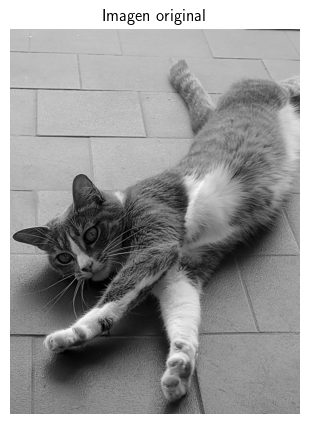

Aplicamos la transformada de Fourier y le aplicamos un filtro del 0.5%.

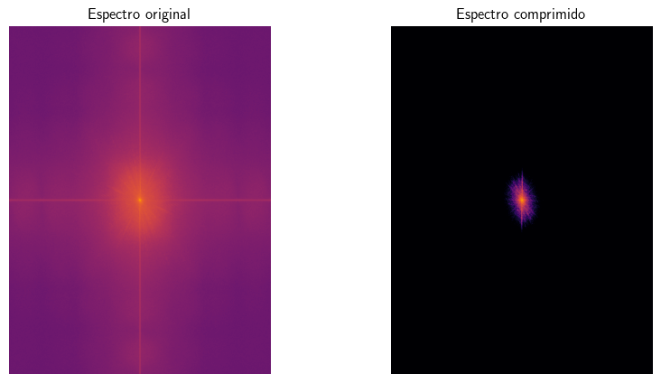

El resultado final es muy similar al de la imagen original, pero ocupa $23$% menos espacio.

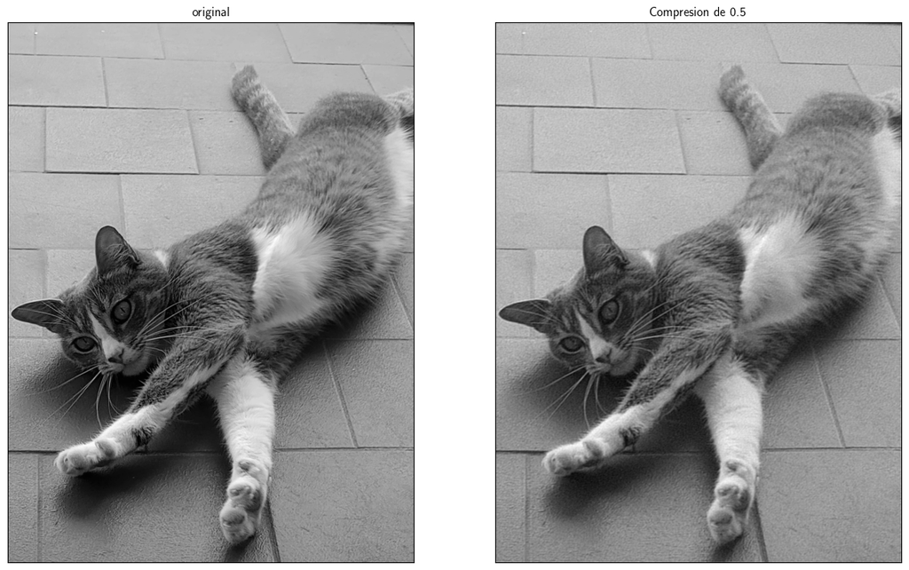

## Aplicaciones a ciencia de datos

### Predicciones de serries de tiempo combinando dominios temporal y frecuencial

Un modelo llamado FFT-LSTM usa FFT para extraer características (amplitud y fase) del dominio de frecuencia, combina esas características con los datos del dominio temporal, y mejora la precisión de la predicción.

Fuente: [Enhancing the FFT-LSTM Time-Series Forecasting Model via a Novel FFT-Based Feature Extraction–Extension Scheme. Yemets, K.; Izonin, I.; Dronyuk, I. (2025).](https://www.mdpi.com/2504-2289/9/2/35)

### Forecasting a largo plazo con redes que atienden la frecuencia

Un modelo híbrido “tiempo-frecuencia” (FFT + otras arquitecturas especializadas) para prever tendencias de series de tiempo en dominios como meteorología, finanzas e industria.

Fuente: [FFTNet: Fusing Frequency and Temporal Awareness in Long-Term Time Series Forecasting. Yang, Zhiqiang et al. (2025).](https://www.mdpi.com/2079-9292/14/7/1303)

### Detección de anomalías usando convoluciones rápidas en frecuencia

Se introduce ‘Fast Fourier Convolutions’ como parte de un sistema de detección de anomalías; se aprovecha la capacidad de la transformada para capturar patrones globales y periódicos que pueden indicar fallas u otros casos extraños.

Fuente: [Introducing Fast Fourier Convolutions into Anomaly Detection. Zhao, Z.; Zhou, J. (2025).](https://www.mdpi.com/1424-8220/25/16/5196)

### Detección de anomalías en ruedas de tren mediante STFT

Usan la Transformada de Fourier de Tiempo Corto (STFT) para extraer características tiempo-frecuencia de señales de vibración, lo cual permite identificar defectos sin supervisión (sin necesidad de muchos ejemplos de fallo).

Fuente: [Anomaly detection of train wheels utilizing short-time Fourier transform and unsupervised learning algorithms. Wan, Ting Hei et al. (2023).](https://eprints.qut.edu.au/241676/?utm_source=chatgpt.com)

## Conclusion

Las Series y Transformadas de Fourier nos muestran una idea poderosa y simple:

**Cualquier señal o imagen puede describirse como una combinación de frecuencias.**

La Serie de Fourier nos permite entender cómo una función periódica se compone de senos y cosenos.

La Transformada de Fourier generaliza esta idea a cualquier señal, incluso no periódica, revelando su contenido en el dominio de la frecuencia.

En la práctica, esta herramienta es esencial en ciencia de datos, procesamiento de señales, compresión de imágenes y audio, filtrado de ruido y análisis de patrones.

En resumen, Fourier nos enseña que, al mirar un problema desde otra perspectiva (el espacio de frecuencias) podemos encontrar soluciones más simples, más eficientes y a menudo más elegantes.

# FIN

[figure not shown]